# Lab 1.3: Starting an analysis

July 2023

# Contents

Authors: Martin Morgan, Sonali Arora, Lori Shepherd  
Back: Intro labs

**Objective**: An overview of software available in *Bioconductor*.

**Lessons learned**:

- How to discover *CRAN* and *Bioconductor* packages
- Finding vignettes, workflows, and tutorials
- Exploring an existing analysis
- Approaching your own data
- How to get help

# 1 *Bioconductor*

Analysis and comprehension of high-throughput genomic data

- Statistical analysis: large data, technological artifacts, designed experiments; rigorous
- Comprehension: biological context, visualization, reproducibility
- High-throughput
  - Sequencing: RNASeq, ChIPSeq, variants, copy number, …
  - Microarrays: expression, SNP, …
  - Flow cytometry, proteomics, images, …

## 1.1 Packages, vignettes, work flows

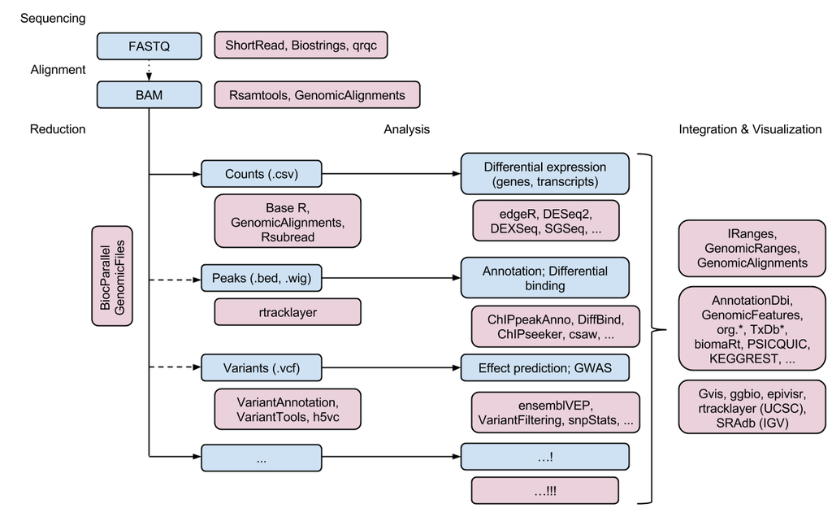

Alt Sequencing Ecosystem

- 1750 software packages
- Discover and navigate via [biocViews](http://bioconductor.org/packages/release/BiocViews.html#___Software)
- Package ‘landing page’, e.g., *Gviz*
  - Title, author / maintainer, short description, citation, installation instructions, …, download statistics
- All user-visible functions have help pages, most with runnable examples
- ‘Vignettes’ an important feature in *Bioconductor* – narrative documents illustrating how to use the package, with integrated code
  - Example: `AnnotationHub` [landing page](https://bioconductor.org/packages/AnnotationHub) references [HOW-TO vignette](http://bioconductor.org/packages/devel/bioc/vignettes/AnnotationHub/inst/doc/AnnotationHub-HOWTO.html) illustrating some fun use cases.
  - Some are extensive; check out Gviz, limma, edgeR, DESeq2!
- ‘Release’ (every six months) and ‘devel’ branches

# 2 Packages

## 2.1 Finding packages

‘Domain-specific’ analysis

**Exercise**

- Visit the listing of [All Packages](https://bioconductor.org/packages/release/BiocViews.html#___Software).
- Use the ‘Search biocViews’ box in the upper left to identify packages that have been tagged for RNASeq analysis. Explore other analysis like ChIPSeq, Epigenetics, VariantAnnotation, Proteomics, SingleCell, etc. Explore the graph of software packages by expanding and contracting individual terms.
- Return to RNASeq. Two very popular packages are DESeq2 and edgeR. Visit the ‘landing page’ of one of these packages. The landing page has a title, authors, instructions for citing use the package, etc.
- Breifly explore the vignette and reference manual links. When would you consult the vignette? When would the reference manual be helpful?

*Bioconductor* provides ‘infrastructure’ for working with genomic data. We’ll explore some of these in more detail in a later part of this lab. For now…

**Exercise**

- Visit the landing pages of each of the Biostrings, GenomicRanges, VariantAnnotation, and GenomicAlignments packages. Create a short summary describing what each package does, and when it might be useful.
- Visit the landing page for the SummarizedExperiment package. This package is meant to provide a data representation that helps manage, in a coordinated fashion, ‘assays’ (e.g., gene x sample matrix of RNASeq counts) and the row (e.g., genomic coordinates, P-values) and column (e.g., sample sheets). Briefly review the user-oriented vignette (‘SummarizedExperiment for Coordinating Experimental Assays, Samples, and Regions of Interest’) to get a sense for how this package might be used.
- Visit the landing page for the rtracklayer package. From the reference manual, when would the various `import()` and `export()` functions be useful?

Annotation packages are data-, rather than software-, centric, providing information about the relationship between different identifiers, gene models, reference genomes, etc.

**Exercise**

- On the page listing [All Packages](https://bioconductor.org/packages/release/BiocViews.html#___Software), click on the AnnotationData top-level term.
- Search, using the box on the right-hand side, for annotation packages that start with the following letters to get a sense of the packages and organisms available.
  - `org.*`: symbol mapping
  - `TxDb.*` and `EnsDb.*`: gene models
  - `BSgenome.*`: reference genomes

We’ll see in a subsequent lab that a wealth of additional annotation resources, including updated EnsDb and reference genomes, are available through AnnotationHub.

Workflow packages are meant to provide a comprehensive introduction to work flows that require several different packages. These can be quite extensive documents, providing a very rich source of information.

**Exercise**

- Briefly explore the ‘Simple Single Cell’ workflow (or other workflow relevant to your domain of interest) to get a sense of the material the workflow covers.

## 2.2 Installing packages

Likely the packages needed for this course are already installed. Nonetheless it is useful to know how to install other packages.

*Bioconductor* has a particular approach to making packages available. We have a ‘devel’ branch where new packages and features are introduced, and a ‘release’ branch where users have access to stable packages. Each six months, in spring and fall, the current ‘devel’ version of packages is branched to become the next ‘release’. Packages within a release are tested with one another, so it is important to install packages from the same release. The BiocManager package tries to make it easy to do this.

The first step to package installation is to make sure that the BiocManager package has been installed using standard *R* procedures.

```r
if (!require(BiocManager))
    install.packages("BiocManager", repos = "https://cran.r-project.org")
```

Then, install the package(s) you would like to use

```r
BiocManager::install(c("Biostrings", "GenomicRanges"))
```

BiocManager knows how to install CRAN and github packages, too.

There are several common problems encountered with package installation. Often, packages have been installed using methods different from the one recommended here, and the packages are from different *Bioconductor* releases. This leads to problems when packages from different releases are incompatible with one another.

**Exercise** Verify that your packages are current and installed from the same *Bioconductor* release with

```r
BiocManager::valid()
```

Two common problems are that some packages are too old (a newer version of the package exists) or too new (some packages have been installed using a method other than BiocManager). If there are packages that are too old or too new, it is almost always a good idea to follow the instructions from `BiocManager::valid()` to correct the situation.

## 2.3 Loading and using packages

Packages need to be installed only once for each version of *R* you use, but need to be *loaded* into each new *R* session that you start. Packages are loaded using

```r
library(Biostrings)
```

Whan a package is loaded, it can sometimes generate messages that are informational only, if you are confident this is the case for the packages you’re loading, use `suppressPackageStartupMessages()` for a quieter experience:

```r
suppressPackageStartupMessages({
    library(GenomicRanges)
    library(GenomicAlignments)
})
```

**Exercise** It is usually very helpful to explore package vignettes.

- Visit the vignette of the DESeq2 package, and walk through a few steps to understand what the vignette provides in terms of instructions for starting with the package, functionality the package provides, mathematical and statistical details of the implementation, and how the analysis provided by the package might be extended by other packages in the *Bioconductor* ecosystem. One can visit vignettes through RStudio, or by running commands such as

  ```r
  vignette(package = "DESeq2")
  browseVignettes("DESeq2")
  ```

- Most vignettes are written in such a way that the *R* code of the vignette *must* be correct for the vignette to be produced. The code itself is available in the package. Find the code for the DESeq2 vignette

  ```r
  dir(system.file(package="DESeq2", "doc"))
  ```

  ```
  ## [1] "DESeq2.html" "DESeq2.R"    "DESeq2.Rmd"  "index.html"
  ```

  ```r
  vign <- system.file(package="DESeq2", "doc", "DESeq2.R")
  ```

  open it in RStudio (e.g., using File -> Open File… menu), step through the first few lines of *R* code and compare your output to the output in the vignette. Alternatively, run the entire analysis in the vignette with the command

  ```r
  source(vign, echo = TRUE, max.lines = Inf)
  ```

- Load the Biostrings package

  ```r
  library(Biostrings)
  ```

- Look for help on the function `letterFrequency()` using the command

  ```
  ?letterFrequency
  ```

  note that there is tab completion after the `?` and first few letters of the command.
- The help page is quite complicated, documenting several different functions. In the ‘Description’ section, find a description of what `letterFrequency()` does. In the ‘Usage’ section, find the arguments that can be used with `letterFrequency()`, and try to understand, from the `Arguments` section what each argument might be or how it influences the computation. The `Value` section attempts to describe the return value of the `letterFrequency()` function.
- Sometimes an example is worth a thousand words. Can you run the first two sections of the example at the end of the help page (for `alphabetFrequency()` and `letterFrequency()` to arrive at a better understanding of how the `letterFrequency()` function works?

# 3 Getting help

Where to get help?

- Most questions from users: https://support.bioconductor.org

What can you get help on?

- Problems on how to use software
- Statistical interpretation of results
- But not: extensive statistical consultation on, e.g., advanced experimental design. Best source: local experts and collaborators.

How to ask a good question

- Simplify to just a few lines of *R* code.
- Must be able to be run by someone else
  - Use built-in data sets or simple simulations
  - Don’t reference files on your system!
- include the output of `sessionInfo()`, which often shows problems with out-of-date packages.

**Exercise** Visit the support site and review the five most recent questions. Which do you think are ‘good’, from the guidelines offered above? Which have received helpful answers? Can you figure out who the person answering the question is, i.e., why do they think they have an answer?

# 4 A sequence analysis package tour

This very open-ended topic points to some of the most prominent *Bioconductor* packages for sequence analysis. Use the opportunity in this lab to explore the package vignettes and help pages highlighted below; many of the material will be covered in greater detail in subsequent labs and lectures.

Basics

- *Bioconductor* packages are listed on the [biocViews](http://bioconductor.org/packages/release/BiocViews.html#___Software) page. Each package has ‘biocViews’ (tags from a controlled vocabulary) associated with it; these can be searched to identify appropriately tagged packages, as can the package title and author.
- Each package has a ‘landing page’, e.g., for GenomicRanges. Visit this landing page, and note the description, authors, and installation instructions. Packages are often written up in the scientific literature, and if available the corresponding citation is present on the landing page. Also on the landing page are links to the vignettes and reference manual and, at the bottom, an indication of cross-platform availability and download statistics.
- A package needs to be installed once, using the instructions on the landing page. Once installed, the package can be loaded into an R session and the help system queried interactively, as outlined above:

```r
library(GenomicRanges)
```

```r
help(package="GenomicRanges")
vignette(package="GenomicRanges")
vignette(package="GenomicRanges", "GenomicRangesHOWTOs")
?GRanges
```

Domain-specific analysis – explore the landing pages, vignettes, and reference manuals of two or three of the following packages.

- Important packages for analysis of differential expression include edgeR and DESeq2; both have excellent vignettes for exploration. Additional research methods embodied in *Bioconductor* packages can be discovered by visiting the [biocViews](http://bioconductor.org/packages/release/BiocViews.html#___Software) web page, searching for the ‘DifferentialExpression’ view term, and narrowing the selection by searching for ‘RNA seq’ and similar.
- Single-cell ‘omics are increasingly important. From the [biocViews](http://bioconductor.org/packages/release/BiocViews.html#___Software) page, enter ’single cell’ in the ‘search table’ field. Check out the [single-cell workflow](http://bioconductor.org/packages/release/workflows/html/simpleSingleCell.html) for an overview of key packages.
- Popular ChIP-seq packages include DiffBind and csaw for comparison of peaks across samples, ChIPQC for quality assessment, and ChIPpeakAnno and ChIPseeker for annotating results (e.g., discovering nearby genes). What other ChIP-seq packages are listed on the [biocViews](http://bioconductor.org/packages/release/BiocViews.html#___Software) page?
- Working with called variants (VCF files) is facilitated by packages such as VariantAnnotation, VariantFiltering, and ensemblVEP; packages for calling variants include, e.g., h5vc and VariantTools.
- Several packages identify copy number variants from sequence data, including cn.mops; from the [biocViews](http://bioconductor.org/packages/release/BiocViews.html#___Software) page, what other copy number packages are available? The CNTools package provides some useful facilities for comparison of segments across samples.
- Microbiome and metagenomic analysis is facilitated by packages such as phyloseq and metagenomeSeq.
- Metabolomics, chemoinformatics, image analysis, and many other high-throughput analysis domains are also represented in *Bioconductor*; explore these via biocViews and title searches.

Working with sequences, alignments, common web file formats, and raw data; these packages rely very heavily on the IRanges / GenomicRanges infrastructure that we will encounter later in the course.

- The Biostrings package is used to represent DNA and other sequences, with many convenient sequence-related functions. Check out the functions documented on the help page `?consensusMatrix`, for instance. Also check out the BSgenome package for working with whole genome sequences, e.g., `?"getSeq,BSgenome-method"`
- The GenomicAlignments package is used to input reads aligned to a reference genome. See for instance the `?readGAlignments` help page and `vigentte(package="GenomicAlignments", "summarizeOverlaps")`
- The rtracklayer `import` and `export` functions can read in many common file types, e.g., BED, WIG, GTF, …, in addition to querying and navigating the UCSC genome browser. Check out the `?import` page for basic usage.
- The ShortRead and Rsamtools packages can be used for lower-level access to FASTQ and BAM files, respectively.
- Many genomics data files are very large. We’ll explore strategies of *restriction* (only input some of the data in the file) and *iteration* (read the file in chunks, rather than its entirety) for processing large data in other labs.

Annotation: *Bioconductor* provides extensive access to ‘annotation’ resources (see the AnnotationData biocViews hierarchy); these are covered in greater detail in Thursday’s lab, but some interesting examples to explore during this lab include:

- biomaRt, PSICQUIC, KEGGREST and other packages for querying on-line resources; each of these have informative vignettes.
- AnnotationDbi is a cornerstone of the [Annotation Data](http://bioconductor.org/packages/release/BiocViews.html#___AnnotationData) packages provided by *Bioconductor*.
  - **org** packages (e.g., org.Hs.eg.db) contain maps between different gene identifiers, e.g., ENTREZ and SYMBOL. The basic interface to these packages is described on the help page `?select`
  - **TxDb** packages (e.g., TxDb.Hsapiens.UCSC.hg38.knownGene) contain gene models (exon coordinates, exon / transcript relationships, etc) derived from common sources such as the hg38 knownGene track of the UCSC genome browser. These packages can be queried, e.g., as described on the `?exonsBy` page to retrieve all exons grouped by gene or transcript.
  - **EnsDb** packages and databases (e.g. EnsDb.Hsapiens.v86) provide, similar to TxDb packages, gene models, but also protein annotations (protein sequences and protein domains within these) and additional annotation columns such as `"gene_biotype"` or `"tx_biotype"` defining the *biotype* of the features (e.g. lincRNA, protein_coding, miRNA etc). EnsDb databases are designed for [Ensembl](http://www.ensembl.org) annotations and contain annotations for all genes (protein coding and non-coding) for a specific Ensembl release.
  - **BSgenome** packages (e.g., BSgenome.Hsapiens.UCSC.hg38) contain whole genomes of model organisms.
- VariantAnnotation and ensemblVEP provide access to sequence annotation facilities, e.g., to identify coding variants; see the [Introduction to VariantAnnotation](http://bioconductor.org/packages/release/bioc/vignettes/ShortRead/inst/doc/Overview.pdf) vignette for a brief introduction; we’ll re-visit this during the Thursday lab.
- Take a quick look (there are more activites in other labs) at the [annotation work flow](http://bioconductor.org/help/workflows/annotation/annotation/) on the *Bioconductor* web site.

A number of *Bioconductor* packages help with visualization and reporting, in addition to functions provided by indiidual packages.

- Gviz provides a track-like visualization of genomic regions; it’s got an amazing vignette.
- ComplexHeatmap does an amazing job of all sorts of heatmaps, including OncoPrint-style summaries.
- ReportingTools provides a flexible way to generate static and dynamic HTML-based reports.

# 5 End matter

## 5.2 Acknowledgements

Research reported in this tutorial was supported by the National Human Genome Research Institute and the National Cancer Institute of the National Institutes of Health under award numbers U24HG004059 (Bioconductor), U24HG010263 (AnVIL) and U24CA180996 (ITCR).